# Association Analysis

#### Market Basket Analysis is one of the key techniques used by large retailers to uncover associations between items . They try to find out the association between different items and products that can be sold together in a right placement.

#### Association rule mining can be thought of if -> then relationship ,

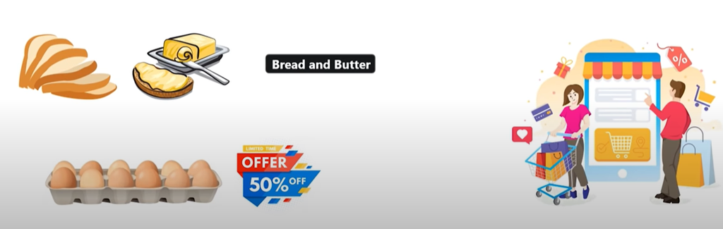

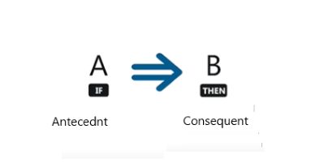

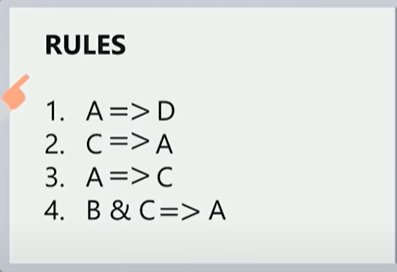

#### So The profit lies of generating the effective rules . Let's discuss that below

# Support

#### Support is an important measure in determining the association rules for our data mining

#### Support is an indication of how frequently the itemset appears in the dataset.

#### Support: is the percentage of transactions in T that contain your set eg :{1,2}

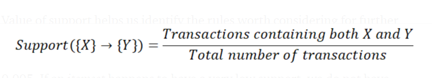

#### during manual calcluation of support for our problem we just take the numerator (i.e no of transactions containing X and Y ) ss our denominators are going to be same for all the support values

The support of $X$ with respect to $T$ is defined as the proportion of transactions $t$ in the dataset which contains the itemset $X$.

# Confidence

#### Confidence is an indication of how often the rule has been found to be true

#### Confidence is defined as:

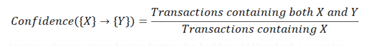

#### hence the confidence parameter is used after determining the association rules using our Apriori , Eclat or FP-Growth to check that the frequent set has passsed our estimated confidence value

#### the confidence value is set by the company or we can set our own value say (60% ) to frame effective assocaition rules

# Lift

#### The lift parameter gives you the strength of your rule , it gives a score value for each of your rule thereby helps in lifting the important rules

#### we use this paramerter to filter out the rules . we use this filtering parameter, if we have a large number of rules framed out after a given support and confidence value

#### below are the formulas if A => B

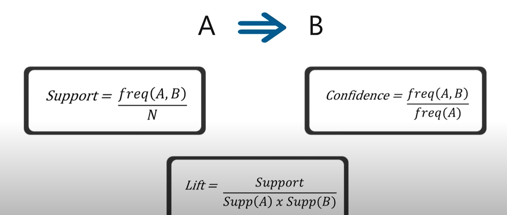

#### from the formula , the denominator focuses on the randomness of A and B , considered seperately

#### consider below dataset

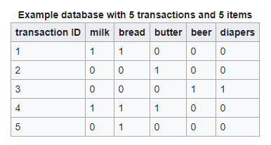

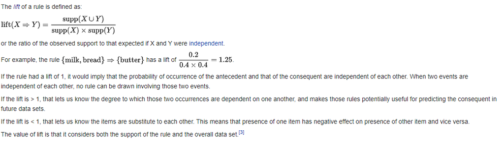

# So how to get the Association rules from our data ? ?

#### for that we have several algorithms like Apriori , Eclat , FP-Growth

# Apriori

### Edureka :

#### Apriori algorithm uses frequent item set to generate association rules , so it is based on the concept that a subset of frequent itemset is also a frequent item set .

#### A frequent item set is an item set in which a support value is greater than the threshold value

### Geeks for geeks :

#### All non-empty subset of frequent itemset must be frequent. All subsets of a frequent itemset must be frequent(Apriori propertry).

#### If an itemset is infrequent, all its supersets will be infrequent.

### Wikipedia :

#### Apriori is an algorithm for frequent item set mining and association rule learning over relational databases. It proceeds by identifying the frequent individual items in the database and extending them to larger and larger item sets as long as those item sets appear sufficiently often in the database.

#### The frequent item sets determined by Apriori can be used to determine association rules which highlight general trends in the database: this has applications in domains such as market basket analysis.

# Working of Apriori

#### let's consider the below dataset to which we need to get the association rules

#### the minsup() , let's consider support threshold to be 2 for our problem

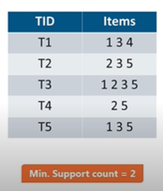

#### Step 1) framing the Item set of size of 1 as below

#### where c is candidate item set and F is frequency item set

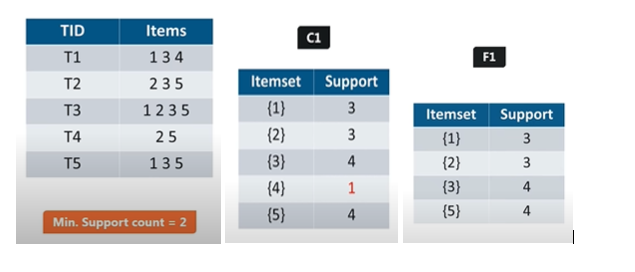

#### Step 2) framing the Item set of size of 2 as below

#### we reject the sets that marked in red as they do not pass the minimum threshold

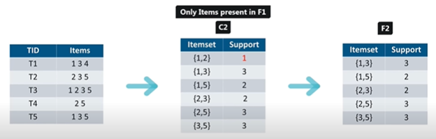

#### Step 3) framing the Item set of size of 3 as below

#### we consider items from f2 for constructing c3

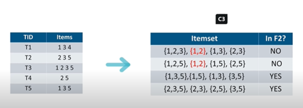

#### before moving further , we perfom a pruning step by taking the subsets of our size 3 item set , so that we can now reject the whole set as the subset has already failed the minsup()

#### hence the size 3 item set is

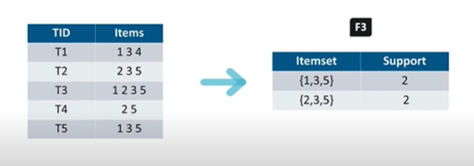

#### Constructing the fourth candidate table below , we see that the support value is less than the minsup() or threshold so stop at f3

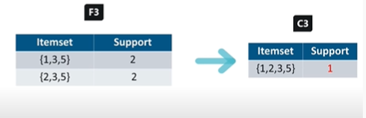

#### So now our frequent item set is {1,3,5} and {2,3,5}

#### Lets consider that our minimum confidence value is 60 % that we use to generate rules from the frequent item set

#### Now lets take the subsets of frequent item sets and check their confidence level if they pass the estimated 60% or not

#### The subsets for f3 are

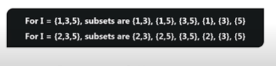

#### applying our confidence parameter filter

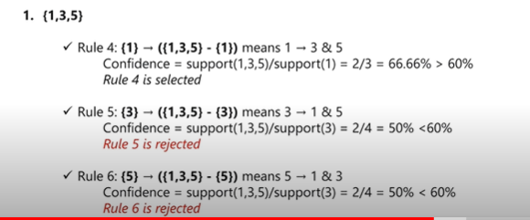

[figure not shown]

#### Apriori uses the breadth first search method and hence will go through whole data everytime it generates the rule

#### to overcome this disadvantage , Eclat and FP-growth have better rule generating strategies